# Meta Analysis

ChatGPT 4o

2025-01-21

## 1 起源

Meta分析（Meta-analysis）是一种统计方法，用于系统地综合多个独立研究的结果，以得出关于某个研究问题的总体结论。Meta分析最早由统计学家Gene V. Glass在1976年提出，他将其定义为一种定量综述方法，以解决不同研究结果之间的不一致性。随着研究方法学的发展，Meta分析已成为医学、心理学、教育学等领域中重要的研究工具，用于量化和总结已有证据的总体效应。

## 2 原理

Meta分析的核心原理是通过系统地收集、整理和定量分析多个独立研究的统计结果，以获得总体的效应估计和结论。Meta分析包括以下几个主要步骤：

- **文献检索与筛选**：通过系统检索相关的文献，筛选符合纳入标准的研究。
- **数据提取与整理**：从每个纳入的研究中提取关键信息，如样本量、效应量、标准误等。
- **效应量的计算**：Meta分析中使用的效应量取决于研究类型和目标，常见的效应量包括：
  - **标准化均数差（Standardized Mean Difference, SMD）**：用于比较不同研究中的连续型变量的效应，尤其是当测量工具不同的情况下。
  - **比值比（Odds Ratio, OR）**：用于二分类结果的比较，表示事件在实验组和对照组中发生的相对概率。
  - **相对风险（Relative Risk, RR）**：用于评估实验组相对于对照组发生事件的风险大小。
  - **加权均数差（Weighted Mean Difference, WMD）**：用于比较同类型量表下的均数差异。 在Meta分析中，效应量通常采用加权平均的方法进行合并，以保证每个研究对总体效应量的贡献与其样本量和质量成正比。
- **异质性检验**：Meta分析中各研究结果的差异性称为异质性，主要通过以下方法检验：
  - **Q统计量**：
    $$Q = \sum_{i=1}^k w_i (TE_i - \bar{TE})^2$$
    其中，$w_i$ 为每个研究的权重，$TE_i$ 为效应量，$\bar{TE}$ 为合并效应量。Q统计量服从卡方分布，用于检验各研究之间的差异是否显著。
  - **I²统计量**：
    $$I^2 = \frac{Q - (k - 1)}{Q} \times 100%$$
    其中，$k$ 为纳入研究的数量。I²值用于量化异质性的程度，取值范围为0%到100%。通常，I²大于50%表示存在中到高程度的异质性。
  - **异质性来源分析**：如果存在显著异质性，通常需要进一步进行亚组分析或元回归来探索异质性的来源。
- **合并效应量的计算**：根据研究的异质性，选择合适的模型来合并效应量：
  - **固定效应模型**：假设所有研究的效应量是相同的，仅考虑研究内的随机误差。其合并效应量的公式为：
    $$\hat{TE}_{fixed} = \frac{\sum_{i=1}^k w_i TE_i}{\sum_{i=1}^k w_i}$$
    其中，$w_i = \frac{1}{SE_i^2}$ 为研究$i$的权重，$SE_i$ 是效应量的标准误。
  - **随机效应模型**：考虑研究之间的真实差异，即每个研究的效应量来自不同的总体。随机效应模型通过加入异质性方差（$\tau^2$）来反映研究间的变异性，其合并效应量的公式为：
    $$\hat{TE}_{random} = \frac{\sum_{i=1}^k w_i^* TE_i}{\sum_{i=1}^k w_i^*}$$
    其中，$w_i^* = \frac{1}{SE_i^2 + \tau^2}$，$\tau^2$ 为异质性方差，通过方法如DerSimonian-Laird（DL）估计得到。
- **发表偏倚检验**：发表偏倚是指正向结果更容易发表，从而影响Meta分析的结论。主要通过以下方法进行检验：
  - **漏斗图（Funnel Plot）**：将效应量与标准误作图，如果不存在发表偏倚，漏斗图应呈对称形状。偏倚会导致漏斗图不对称。
  - **Egger回归检验**：一种定量的方法，用于检验漏斗图的不对称性是否显著。

## 3 适用范围

Meta分析适用于以下情况：

- **多个研究的综合**：适合对某一研究问题已有多个独立研究结果进行综合分析，以提供总体的效应量。
- **解决研究结果的异质性**：当不同研究对同一问题得出不同结果时，Meta分析可用于定量地评估异质性并得出总体结论。
- **评估干预措施的总体效果**：在临床试验中，Meta分析常用于评估某种干预措施（如药物、治疗手段）的总体效果。

## 4 应用情境

Meta分析在多个领域中有广泛的应用，例如：

- **医学与公共卫生**：用于评估药物、治疗方法的总体疗效，指导临床决策和制定公共卫生政策。
- **心理学与教育学**：用于量化心理干预、教育方法的总体效应，评估不同干预措施的有效性。
- **社会科学**：用于整合社会调查、行为研究等领域的多项研究结果，为政策制定提供支持。

## 5 优缺点

### 优点

- **提高统计效能**：通过综合多个研究的数据，Meta分析能够提高总体效应量的统计效能。
- **解决不一致性**：Meta分析可以定量地评估不同研究之间的异质性，帮助理解结果不一致的原因。
- **提供更全面的结论**：通过整合多项研究，Meta分析可以提供更全面和稳健的结论，具有较高的外部效度。

### 缺点

- **发表偏倚**：由于发表倾向于正结果的研究，Meta分析的结论可能受到发表偏倚的影响。
- **异质性问题**：不同研究之间的异质性可能会影响Meta分析结果的稳健性，尤其是在采用固定效应模型时。
- **数据质量依赖性**：Meta分析的质量取决于纳入研究的质量，如果纳入研究存在系统误差，Meta分析结果也可能受到影响。

## 6 在R中的实现及结果解释

在R中，可以使用`meta`包中的`metagen()`函数进行Meta分析。以下是一个实现Meta分析的示例：

```r
# 加载必要的包
library(meta)
```

```r
library(ggplot2)

# 示例数据：创建效应量和标准误的数据
study_data <- data.frame(
  study = paste("Study", 1:5),
  effect_size = c(0.5, 0.6, 0.2, 0.8, 0.4),
  se = c(0.1, 0.15, 0.2, 0.12, 0.18)
)

# 进行Meta分析
meta_result <- metagen(TE = effect_size, seTE = se, studlab = study, data = study_data, common = TRUE, random = TRUE, method.tau = "DL")

# 输出Meta分析结果
summary(meta_result)
```

```
##                           95%-CI %W(common) %W(random)
## Study 1 0.5000 [ 0.3040; 0.6960]       37.1       27.0
## Study 2 0.6000 [ 0.3060; 0.8940]       16.5       19.4
## Study 3 0.2000 [-0.1920; 0.5920]        9.3       13.9
## Study 4 0.8000 [ 0.5648; 1.0352]       25.7       23.7
## Study 5 0.4000 [ 0.0472; 0.7528]       11.4       15.9
##
## Number of studies: k = 5
##
##                                       95%-CI    z  p-value
## Common effect model  0.5545 [0.4351; 0.6738] 9.11 < 0.0001
## Random effects model 0.5329 [0.3505; 0.7153] 5.73 < 0.0001
##
## Quantifying heterogeneity (with 95%-CIs):
##  tau^2 = 0.0221 [0.0000; 0.3651]; tau = 0.1486 [0.0000; 0.6042]
##  I^2 = 52.7% [0.0%; 82.6%]; H = 1.45 [1.00; 2.40]
##
## Test of heterogeneity:
##     Q d.f. p-value
##  8.45    4  0.0763
##
## Details of meta-analysis methods:
## - Inverse variance method
## - DerSimonian-Laird estimator for tau^2
## - Jackson method for confidence interval of tau^2 and tau
## - Calculation of I^2 based on Q
```

```r
str(meta_result)
```

[output not shown]

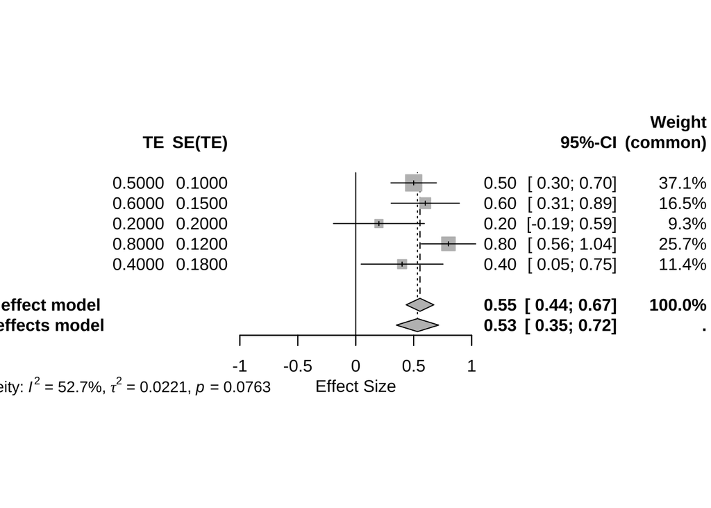

```r
# 绘制森林图（Forest Plot）
forest(meta_result, xlab = "Effect Size")
```

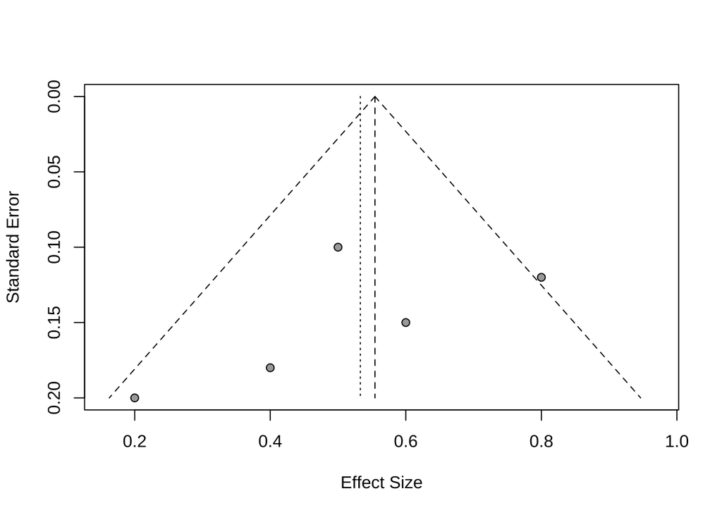

```r
# 绘制漏斗图（Funnel Plot）
funnel(meta_result, xlab = "Effect Size", ylab = "Standard Error")
```

### 结果解释

- **Meta分析结果**：`summary(meta_result)` 输出中包含固定效应模型和随机效应模型的合并效应量、异质性检验结果（Q统计量、I²值）以及各个研究的效应量和置信区间。
- **异质性检验**：通过I²值可以判断研究间的异质性程度。I²值越高，说明异质性越大，可能需要选择随机效应模型。
- **森林图（Forest Plot）**：`forest()` 函数用于绘制森林图，展示各研究的效应量及其置信区间，以及合并效应量，便于直观比较各个研究的结果。

### 结果的可视化

可以通过森林图和漏斗图对Meta分析的结果进行可视化，以直观展示每个研究的效应量、总体效应量及发表偏倚情况。

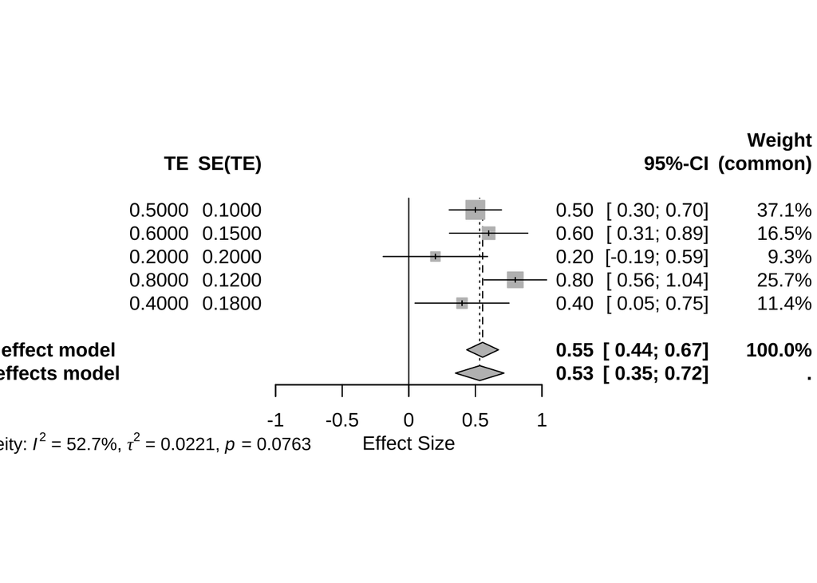

```r
# 绘制森林图（Forest Plot）
forest(meta_result, xlab = "Effect Size")
```

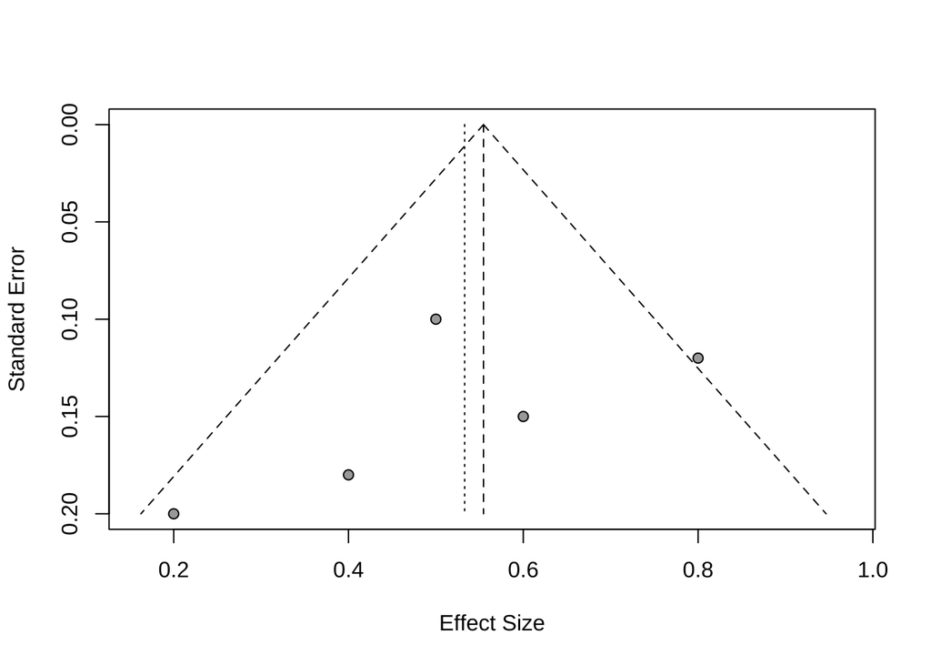

```r
# 绘制漏斗图（Funnel Plot）
funnel(meta_result, xlab = "Effect Size", ylab = "Standard Error")
```

上述代码生成森林图和漏斗图，森林图展示了各研究的效应量及其置信区间，总体效应量以钻石形状表示，便于观察各研究结果的一致性；漏斗图则用于检查发表偏倚的存在与否。

## 7 小结

- Meta分析是一种用于综合多个独立研究结果的统计方法，广泛应用于医学、心理学、社会科学等领域。
- 适用于多个研究结果的综合，特别是在不同研究结果存在异质性的情况下。
- 具有提高统计效能、解决不一致性、提供全面结论等优点，但可能受到发表偏倚、异质性和数据质量的影响。
- 可以通过R中的`metagen()`函数实现Meta分析，并结合森林图和漏斗图直观展示结果。
- Meta分析在为临床决策和政策制定提供综合证据方面具有重要作用，是系统综述中的关键步骤。